# Aula_1

### Aluno: **Fernando Gomes Papi**

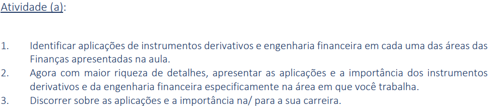

#### 1)

- 1. Finanças Corporativas:
  - Proteger-se contra movimentos adversos nos preços de ativos subjacentes, como commodities ou moedas estrangeiras.
  - Proteger-se contra flutuações cambiais, minimizando o impacto adverso nos resultados financeiro para empresas exportadoras
  - Gerenciar o estoque de produtos acabados, permitindo que vendam produtos a um preço garantido mesmo em situações de volatilidade de preços.
  - Ajudar a definir estrutura de capital, estruturando dívidas, equity, etc.
- 2. Investimentos:
  - Proteger suas carteiras contra movimentos adversos nos preços de ativos subjacentes
  - Investidores que desejam ampliar seus retornos podem usar derivativos para alavancar suas posições
  - Investidores podem usar derivativos para implementar estratégias de mercado, como arbitragem, especulação e neutralidade de mercado
  - Investidores podem usar derivativos, como swaps de inflação, para se proteger contra o risco de inflação afetar seus retornos reais.
- 3. Mercados/Instituições Financeiros:
  - Instituições financeiras usam derivativos para gerenciar riscos relacionados a flutuações de taxas de juros, câmbio, commodities e outros ativos. Isso ajuda a reduzir a exposição a movimentos adversos nos preços.
  - Os traders financeiros podem usar derivativos para explorar discrepâncias nos preços dos ativos em diferentes mercados ou instrumentos, buscando lucrar com essas diferenças de preço.
  - As instituições financeiras podem criar produtos estruturados que combinam derivativos com outros instrumentos financeiros para atender às necessidades específicas de seus clientes.
  - Instituições financeiras, bem como empresas envolvidas em comércio de commodities, usam derivativos para gerenciar os riscos associados às flutuações nos preços de commodities.

#### 2)

**Área que trabalho: Concessão de crédito / Trading Quantitativo**

Há duas semanas estou trabalhado em uma empresa de concessão de crédito para pequenos e-commerces. Assim, pode-se utilizar derivativos para:

- Gestão de Risco de Taxa de Juros: Instituições financeiras que concedem empréstimos a taxas variáveis podem usar derivativos, como swaps de taxa de juros, para proteger-se contra o risco de flutuações nas taxas de juros. Isso ajuda a garantir uma margem de lucro estável, independentemente das mudanças nas taxas.
- Proteção contra Inadimplência: Derivativos de crédito, como swaps de inadimplência (CDS), podem ser usados para proteger a instituição financeira contra o risco de inadimplência do mutuário. Isso pode ajudar a reduzir a exposição a perdas de crédito.
- Personalização de Condições de Empréstimo: Usando derivativos, as instituições podem personalizar as condições de empréstimo para atender às necessidades específicas dos mutuários. Isso pode incluir opções de pagamento flexíveis ou ajuste de taxas de juros com base em eventos futuros.
- Gestão de Fluxo de Caixa Futuro: Derivativos podem ser usados para gerenciar o fluxo de caixa futuro dos empréstimos, permitindo que a instituição antecipe e proteja contra flutuações nas entradas de caixa.

#### 3)

Aplicações e importância na carreira

Gostaria de seguir minha carreira na intersecção de machine learning e finanças quantitativas. Por isso, precificação de ativos (incluindo-se derivativos) e previsão (forecasting) dos mais diversos aspectos do mercado financeiro (volatilidades, movimentos de preço, volumes negociados, aspectos econômicos, etc) são possibilidades de aplicação destes algoritmos.

Mais especificamente, derivativos contém uma quantidade enorme de informação sobre os ativos subjacentes (por exemplo, no mercado crypto, entre os derivativos PERP x ativo)

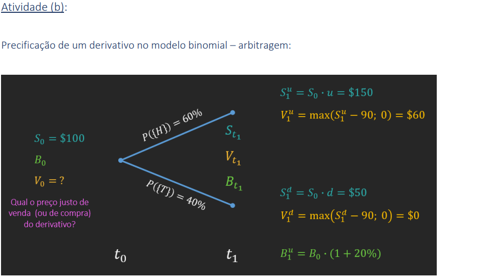

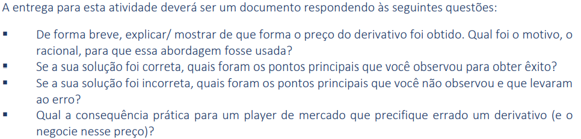

```python
def binomial_option_pricing(S, K, r, T, n, u, d, option_type='call'):
    """
    Calculate the option price using the Binomial Option Pricing Model.

    S: Initial stock price
    K: Strike price
    r: Risk-free interest rate
    T: Time to maturity (in years)
    n: Number of time steps
    option_type: 'call' for call option, 'put' for put option

    Returns the option price.
    """
    dt = T / n

    p = ((1+r) - d) / (u - d)  # Pseudo-Probability of up movement

    option_prices = [[0 for _ in range(n + 1)] for _ in range(n + 1)]

    # Calculate option prices at maturity
    for j in range(n + 1):
        if option_type == 'call':
            option_prices[n][j] = max(0, S * (u ** (n - j)) * (d ** j) - K)
        elif option_type == 'put':
            option_prices[n][j] = max(0, K - S * (u ** (n - j)) * (d ** j))

    # Backward induction to calculate option prices at earlier time steps
    for i in range(n - 1, -1, -1):
        for j in range(i + 1):
            option_prices[i][j] = (1/(1+r)) * (p * option_prices[i + 1][j] + (1 - p) * option_prices[i + 1][j + 1])

    return option_prices[0][0]

# Example usage
S = 100  # Initial stock price
K = 90  # Strike price
r = 0.20  # Risk-free interest rate
T = 1  # Time to maturity
n = 1  # Number of time steps
u = 1.5  # Up factor
d = 0.5  # Down factor

call_option_price = binomial_option_pricing(S, K, r, T, n, u, d, option_type='call')

print(f"Call Option Price: {call_option_price:.2f}")
```

```
Call Option Price: 35.00
```

Obtido através de um modelo simples binomial considerando a pseudo-probabilidade (ao invés da probalidade real) para a obtenção do valor esperado, descontado pela taxa de 20%

Na prática, a precificação incorreta de opções pode causar sérias perdas financeiras

(ps.: código gerado com o chatgpt, corrigido para o caso discreto)